# Snow depth

[NO_SNOW_001]

Authors

Affiliation

Matthew Grainger

Norwegian Institute for Nature Research

Anders Kolstad

Norwegian Institute for Nature Research

Published

June 8, 2026

Reviewed by

Anders Kolstad

> **Recommended citation**: Grainger, M., Kolstad A. 2026. Snow depth (ID(s): NO_SNOW_001) v. 0.1.0. ecRxiv: https://github.com/NINAnor/ecRxiv/tree/main/indicators/NO_SNOW_001

**Metadata**

Table 1: Indicator metadata

| Variable | Value |
| --- | --- |
| Indicator ID | NO_SNOW_001 |
| Indicator Name | Snow depth |
| verbatimEcosystem | Fjell |
| verbatimName | Snødybde |
| Country | Norway |
| Continent | Europe |
| Ecosystem Condition Typology Class | A1 Physical state characteristics |
| Realm | Terrestrial (T) |
| Biome | T6 Polar-alpine (cryogenic) biome |
| Ecosystem | T6.1 Permanent snow; T6.2 Polar/alpine rock; T6.3 Polar tundra; T6.4 Temp alpine grasslands |
| Year added | 2026 |
| Last update | 2026 |
| Version | 0.1.0 |
| Version comment | Snow depth data from seNorge has been used in other indicator version in Norway before, but this is the first version on ecRxiv. |
| Normalised | TRUE |
| Spatial aggregation pathway | Mask - temporal aggregation - spatial aggregation (regional arithmetic mean) - aggregate (national) |
| Precision | Reported as probability distributions for the true indicator value |

**Log**

- 19 Jun. 2026 - First draft of the snow depth indicator workflow using seNorge snow data and regional mountain aggregation.
- 4 July - 2026 Review and input from ALK
- 8 July 2026 - Accepted

## 1. Summary

1. **Background and rationale**: This indicator describes mean winter snow depth in Norwegian mountain ecosystems. Snow depth is a key physical characteristic of mountain ecosystems because it influences the length of the snow season, soil temperatures, freeze-thaw exposure, plant phenology, grazing access, hydrology, and the winter conditions experienced by alpine and subalpine species. Changes in snow depth are closely linked to climate change and can alter ecological processes even where land-use pressure is low.
2. **Methods**: The indicator is calculated from daily seNorge snow depth data. For each “winter year”, snow depth is averaged over the period December of the previous year to May of the current year. The resulting winter mean raster is clipped to the Norwegian mountain area using a mountain mask. Mean snow depth is then calculated separately for five mountain regions: Nord-Norge, Midt-Norge, Østlandet, Vestlandet and Sørlandet.

## 2. About the underlying data

The indicator uses daily snow depth data from seNorge, accessed through the MET Norway THREDDS service. The spatial delineation of mountain areas is based on the national modelled mountain layer `Modellert_fjell_50` from the geodatabase `Fjell_norge_publisering.gdb`. Regional aggregation is based on a helper file containing five mountain regions and their estimated mountain area.

### 2.1 Spatial and temporal resolution and extent

The snow depth data are gridded daily raster data covering Norway. In this workflow, daily values are aggregated to a winter-year mean for the period December-May. The first complete winter year in the analysis is 1959, because this uses December 1958 and January-May 1959. The current script is set up to process winter years 1959-2026, depending on data availability from seNorge.

Spatially, the analysis is restricted to modelled mountain areas in Norway. Final indicator values are reported for five broad regions: Nord-Norge, Midt-Norge, Østlandet, Vestlandet and Sørlandet.

### 2.2 Sampling design

The data are modelled gridded climate data rather than field samples collected specifically for this indicator. The indicator therefore inherits uncertainties from the underlying meteorological observations, interpolation/model structure, elevation effects, and the density and distribution of weather stations. Uncertainty may be larger in remote mountain areas where observations are sparse, and in areas where local topography produces fine-scale snow variation that is not fully represented by the raster resolution.

### 2.3 Original units

The underlying variable is snow depth measured in cm.

### 2.4 Instructions for citing, using and accessing data

The snow data are freely available and accessed from the seNorge snow depth NetCDF files hosted through the MET Norway THREDDS service (Norwegian Meteorological Institute 2026). Two datasets are included in this indicator publication under an open licence: The spatial mountain mask is read from `Fjell_norge_publisering.gdb`, layer `Modellert_fjell_50` (Blumentrath and Hanssen 2010). The regional helper file is an `sf` object containing five polygons and an `arealFjell` attribute (CC0).

### 2.5 Additional comments about the dataset

The current script crops remote NetCDF files to the bounding box of the mountain mask before downloading the daily snow depth values. This makes processing substantially faster, but it also means that CRS alignment and raster orientation should be checked carefully. A visual overlay of the winter mean raster and regional polygons should be inspected.

A snow depth indicator was also calculated in an earlier ecosystem assessment of Norwegian alpine ecosystem (Kolstad 2021), and further developed two years later (Kolstad 2023).

## 3. Indicator properties

### 3.1 Ecosystem Condition Typology Class (ECT)

A1 - physical state characteristic

### 3.2 Ecosystem condition characteristic

Intact climate.

### 3.3 Collinearities with other indicators

This indicator is expected to be correlated with other climate-related indicators, including winter temperature, winter precipitation, snow-cover duration, date of snow melt, glacier extent and growing-season length. Rodents and reindeer indicators will also likely be somewhat correlated with this snow depth indicator.

### 3.4 Impact factors

The main impact factor affecting this metric is climate change, particularly changes in winter temperature and precipitation. Natural drivers include elevation, latitude, distance from the coast, topography, wind redistribution of snow, and interannual weather variability. Land use may have local effects on snow accumulation and redistribution, but these effects are not explicitly modelled here.

### 3.5 Spatial aggregation

Daily snow depth values are first temporally aggregated to a winter mean raster for each winter year. The winter mean raster is then masked to mountain areas. Spatial aggregation is carried out by calculating the arithmetic mean of all valid mountain raster cells within each of five mountain regions. The regional indicator values are aggregated to produce a national estimate.

## 4. Reference condition and levels

### 4.1 Reference condition

The reference condition is defined as the typical winter snow depth observed during the historical reference period 1961–1990. This period is used to represent earlier climatic snow conditions in Norwegian mountain ecosystems before the strongest recent warming signal.

### 4.2 Reference levels

For each region, the x<sub>100</sub> reference level is calculated as the median winter mean snow depth during 1961–1990. The median is used because snow depth can be strongly influenced by unusually snowy or unusually snow-poor winters. x<sub>0</sub> is a complete abscense of snow. x<sub>60</sub> is defined by observed values that are 2 sd units smaller than the snow deoths observed across the reference period. This definition of 2 sd units has been used to define extreme weather events.

#### 4.2.1 Spatial resolution and validity

The reference values unique to each of the five mountain regions. This avoids comparing naturally low-snow regions with naturally high-snow regions. Future versions could develop cell-level reference values before regional aggregation, but the current regional approach is transparent and consistent with the reporting scale of this indicator.

## 5. Uncertainties

### 5.1 General uncertainties

The main uncertainties relate to the underlying seNorge snow depth product, the spatial delineation of mountain areas, the regional aggregation layer, and the ecological interpretation of snow depth as an indicator of condition. Mountain snow depth varies strongly over short distances due to elevation, aspect, wind exposure and local terrain. These fine-scale patterns may not be fully captured in gridded climate data. The indicator is also sensitive to the selected winter period. December-May was chosen to match the previous assessment, but other choices, such as snow-season length or date of melt-out, could represent different ecological mechanisms.

Additional uncertainty arises from the selection of the 1961–1990 reference period and the assumption that historical snow conditions represent a desirable ecological reference state. Different baseline periods or alternative normalisation approaches could produce different condition scores, particularly in regions experiencing strong long-term climatic trends.

### 5.2 Reported uncertainties

Indicator precision in describes by taking the sd of the indicator values across the five years in the reporting period and draw 1000 values from a logit scale, and then backtransform these. This distribution of values represents an inferential uncertainty about the true value of the indicator value.

## 6. References

Blumentrath, S., and F. Hanssen. 2010. [Beregning av areal](https://naturindeks.nina.no/docs/0a91e8ea-c77f-44e2-822f-7f9ced851d4c.pdf). In *Datagrunnlaget for “naturindeks i norge 2010”*, ed. S. Nybø. DN-Utredning 4-2010. Trondheim: Direktoratet for naturforvaltning.

Kolstad, A. 2021. Snødybde. Norwegian Institute for Nature Research; https://ninanor.github.io/IBECA/snodybde.html.

Kolstad, A. L. 2023. Climate indicators explained. Norwegian Institute for Nature Research (NINA); https://ninanor.github.io/ecosystemCondition/climate-indicators-explained.html.

Norwegian Meteorological Institute. 2026. MET norway THREDDS data server. Norwegian Meteorological Institute; https://thredds.met.no/thredds/catalog.html.

## 7. Import and prepare datasets

### 7.1 seNorge snow depth data

The seNorge snow depth data are accessed as annual NetCDF files. For each winter year, the script reads December from the previous year and January-May from the current year. These daily values are combined and averaged to produce a single winter mean snow depth raster.

All the data is imported in Section 9

### 7.2 Mountain mask and regional helper file

The mountain mask is based on the modelled mountain layer `Modellert_fjell_50`. The regional helper file divides the mountain area into five broad regions and includes the region names and mountain area. These polygons are used for the final spatial aggregation.

## 8. Spatial units

The Basic Spatial Units are raster cells in the seNorge snow depth product. The Ecosystem Asset is the modelled mountain area in Norway. The Ecosystem Accounting Area is Norway, with final results reported separately for five mountain regions. Indicator values should be interpreted at the regional scale, not at the individual raster-cell scale, because the final values are regional means across all valid mountain raster cells.

## 9. Analyses

This section imports the spatial layers and retrieves daily snow depth data from seNorge. The workflow processes one winter year at a time to reduce memory use. A winter year is defined as December of the previous calendar year plus January-May of the current calendar year.

```r
# -------------------------------
# 1. LOAD SPATIAL DATA
# -------------------------------

# Mountain area polygons. These are used to mask the snow-depth raster so that
# only mountain areas contribute to the indicator.
fjell <- st_read(here::here(
  "data/Fjell_norge_publisering.gdb"),
  layer = "Modellert_fjell_50"
)

# Regional helper file. This deliminates the firev geographic regions used
# when aggregating mean snow depth to regions.
reg_helperfile <- readRDS(here::here(
  "data/reg_helperfile.rds"
))

reg_helperfile <- st_transform(reg_helperfile, st_crs(fjell))

# Use the mountain-area bounding box to crop the NetCDF data spatially before
# converting it to rasters. This avoids reading the full national grid.
bbox <- st_bbox(fjell)

# -------------------------------
# 2. DEFINE YEARS AND EMPTY OUTPUT
# -------------------------------

# Starts at 1959 because winter 1958 would require Dec 1957.
years <- 1959:2026

results <- data.frame(
  year = integer(),
  id = integer(),
  region = character(),
  arealFjell = numeric(),
  mean_snow = numeric()
)

# -------------------------------
# 3. LOOP THROUGH WINTER YEARS
# -------------------------------

for (yr in years) {

  cat("Processing winter year:", yr, "\n")

  tryCatch({
    # seNorge snow-depth NetCDF files are organised by calendar year.
    # For winter year yr, we need December from yr - 1 and January-May from yr.
    url_prev <- paste0(
      "https://thredds.met.no/thredds/dodsC/senorge/seNorge_snow/sd/sd_",
      yr - 1,
      ".nc"
    )

    url_curr <- paste0(
      "https://thredds.met.no/thredds/dodsC/senorge/seNorge_snow/sd/sd_",
      yr,
      ".nc"
    )

# -------------------------------
# 3a. Read January-May from current calendar year
# -------------------------------
    nc_curr <- nc_open(url_curr)

    time_curr <- ncvar_get(nc_curr, "time")

    dates_curr <- as.POSIXct(
      time_curr,
      origin = "1900-01-01",
      tz = "UTC"
    )

    idx_jan_may <- which(month(dates_curr) %in% 1:5)

    x_vals <- nc_curr$dim$x$vals
    y_vals <- nc_curr$dim$y$vals

    # Identify the grid cells overlapping the mountain-area bounding box.
    x_idx <- which(
      x_vals >= bbox["xmin"] &
        x_vals <= bbox["xmax"]
    )

    y_idx <- which(
      y_vals >= bbox["ymin"] &
        y_vals <= bbox["ymax"]
    )

    # Read snow depth only for the selected spatial extent and months.
    sd_jan_may <- ncvar_get(
      nc_curr,
      "snow_depth",
      start = c(min(x_idx), min(y_idx), min(idx_jan_may)),
      count = c(length(x_idx), length(y_idx), length(idx_jan_may))
    )

    nc_close(nc_curr)

# -------------------------------
# 3b. Read December from previous calendar year
# -------------------------------
    nc_prev <- nc_open(url_prev)

    time_prev <- ncvar_get(nc_prev, "time")

    dates_prev <- as.POSIXct(
      time_prev,
      origin = "1900-01-01",
      tz = "UTC"
    )

    idx_dec <- which(month(dates_prev) == 12)

    sd_dec <- ncvar_get(
      nc_prev,
      "snow_depth",
      start = c(min(x_idx), min(y_idx), min(idx_dec)),
      count = c(length(x_idx), length(y_idx), length(idx_dec))
    )

    nc_close(nc_prev)

# -------------------------------
# 3c. Create winter-season raster stack
# -------------------------------

    # Combine December and January-May
    snow_array <- abind(sd_dec, sd_jan_may, along = 3)

    # Convert array to raster stack.
    # The aperm() and flip() steps correct the orientation of the NetCDF array
    # for use as a terra SpatRaster.
    r <- rast(aperm(snow_array, c(2, 1, 3)))

    ext(r) <- c(
      min(x_vals[x_idx]), max(x_vals[x_idx]),
      min(y_vals[y_idx]), max(y_vals[y_idx])
    )

    crs(r) <- "EPSG:25833"

    r <- flip(r, direction = "vertical")

    # Mean snow depth over the full December-May period
    r_mean <- mean(r, na.rm = TRUE)

# -------------------------------
# 3d. Mask to mountain areas
# -------------------------------
    # Rasterize the mountain polygon layer to the snow-depth raster grid.
    fjell_rast <- rasterize(
      vect(fjell),
      r_mean,
      field = 1
    )
    # Keep only raster cells inside modelled mountain areas.
    r_masked <- mask(r_mean, fjell_rast)

# -------------------------------
# 3e. Aggregate mean snow depth to regions
# -------------------------------
    region_vals <- terra::extract(
      r_masked,
      vect(reg_helperfile),
      fun = mean,
      na.rm = TRUE
    )

    region_results <- cbind(
      st_drop_geometry(reg_helperfile)[, c("id", "region", "arealFjell")],
      mean_snow = region_vals[, 2]
    )

    region_results$year <- yr

    results <- bind_rows(
      results,
      region_results[, c("year", "id", "region", "arealFjell", "mean_snow")]
    )

    # Save after every year so progress is not lost if the loop fails later
    write.csv(
      results,
      "snow_indicator_fjell_by_region_winter_year.csv",
      row.names = FALSE
    )

    # Remove large temporary objects before processing the next year.
    rm(
      sd_dec, sd_jan_may, snow_array,
      r, r_mean, r_masked, fjell_rast,
      region_vals, region_results
    )

    gc()

  }, error = function(e) {
    message("Failed for winter year ", yr, ": ", e$message)
  })
}
```

The main analytical step is the calculation of mean winter snow depth by region. The workflow first creates a winter mean raster for each year, then masks this raster to mountain areas, and finally extracts the arithmetic mean for each region. Then we can normalise the variable (Figure 1).

```r
results <- read.csv(here::here("data/snow_indicator_fjell_by_region_winter_year.csv"))

results |>
  arrange(region, year) |>
  group_by(region) |>
  summarise(
    first_year = min(year, na.rm = TRUE),
    last_year = max(year, na.rm = TRUE),
    mean_snow_all_years = mean(mean_snow, na.rm = TRUE),
    min_snow = min(mean_snow, na.rm = TRUE),
    max_snow = max(mean_snow, na.rm = TRUE),
    .groups = "drop"
  ) |>
  kable(digits = 2)
```

| region | first_year | last_year | mean_snow_all_years | min_snow | max_snow |
| --- | --- | --- | --- | --- | --- |
| Midt-Norge | 1959 | 2026 | 154.44 | 64.05 | 278.96 |
| Nord-Norge | 1959 | 2026 | 141.35 | 69.20 | 207.76 |
| Sørlandet | 1959 | 2026 | 150.18 | 35.09 | 242.88 |
| Vestlandet | 1959 | 2026 | 242.74 | 117.18 | 397.38 |
| Østlandet | 1959 | 2026 | 103.43 | 61.72 | 143.81 |

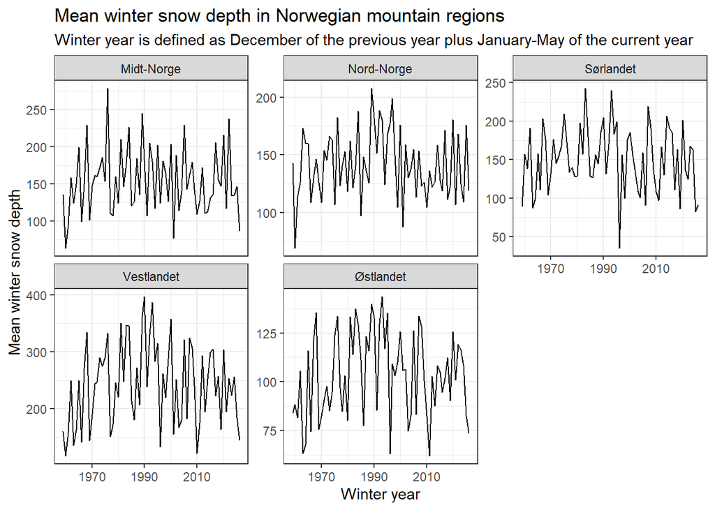

```r
#|echo: true
#|warning: false
#|message: false
#|
ggplot(results, aes(year, mean_snow)) +
  geom_line() +
  facet_wrap(~ region, scales = "free_y") +
  labs(
    x = "Winter year",
    y = "Mean winter snow depth",
    title = "Mean winter snow depth in Norwegian mountain regions",
    subtitle = "Winter year is defined as December of the previous year plus January-May of the current year"
  ) +
  theme_bw()
```

```r
## Define the reference period

reference_years <- 1961:1990

accounting_period_1 <- 2020:2024
accounting_period_2 <- 2015:2019


# Calculate regional reference values
reference_values <- results |>
  dplyr::filter(year %in% reference_years) |>
  group_by(id, region) |>
  summarise(
    reference_snow = median(mean_snow, na.rm = TRUE),
    reference_mean_snow = mean(mean_snow, na.rm = TRUE),
    n_reference_years = sum(!is.na(mean_snow)),
    sd = sd(mean_snow),
    .groups = "drop"
  ) |>
  # calculating reference values with x60 equal to a value that
  # is more extreme than 2 sd units during the reference period
  mutate(
    x100 = reference_snow,
    x0 = 0,
    x60 = reference_snow - (sd * 2)
  )


# Join reference values back to the full results table
results_normalised <- results |>
  left_join(reference_values, by = c("id", "region")) |>
  mutate(
    condition_score = ecTools::ec_normalise(
      mean_snow,
      x0 = x0,
      x60 = x60,
      x100 = x100
    )
  )

# Inspect reference values
reference_values |>
  arrange(id) |>
  kable(
    digits = 2,
    caption = "Regional snow-depth reference values for the 1961–1990 reference period"
  )
```

Regional snow-depth reference values for the 1961–1990 reference period

| id | region | reference_snow | reference_mean_snow | n_reference_years | sd | x100 | x0 | x60 |
| --- | --- | --- | --- | --- | --- | --- | --- | --- |
| 1 | Nord-Norge | 142.92 | 143.74 | 30 | 27.20 | 142.92 | 0 | 88.53 |
| 2 | Midt-Norge | 156.55 | 160.91 | 30 | 45.38 | 156.55 | 0 | 65.80 |
| 3 | Østlandet | 104.27 | 104.20 | 30 | 23.59 | 104.27 | 0 | 57.10 |
| 4 | Vestlandet | 247.24 | 247.79 | 30 | 74.45 | 247.24 | 0 | 98.34 |
| 5 | Sørlandet | 155.90 | 156.04 | 30 | 36.39 | 155.90 | 0 | 83.13 |

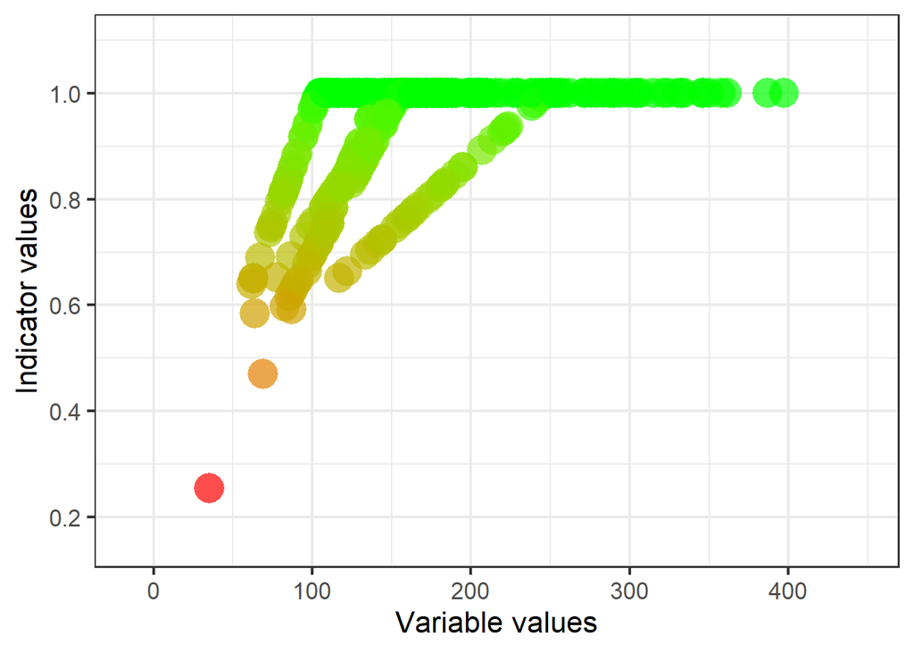

Figure 1: Figure showing the normalisation of variable values into indicator values, using a region specific piece-wise linear transformation.

```r
ec_norm_plot(
  variable = results_normalised$mean_snow,
  indicator = results_normalised$condition_score
)
```

We can now plot the anomalies in alipne snow depth relative to the reference period (Figure 2).

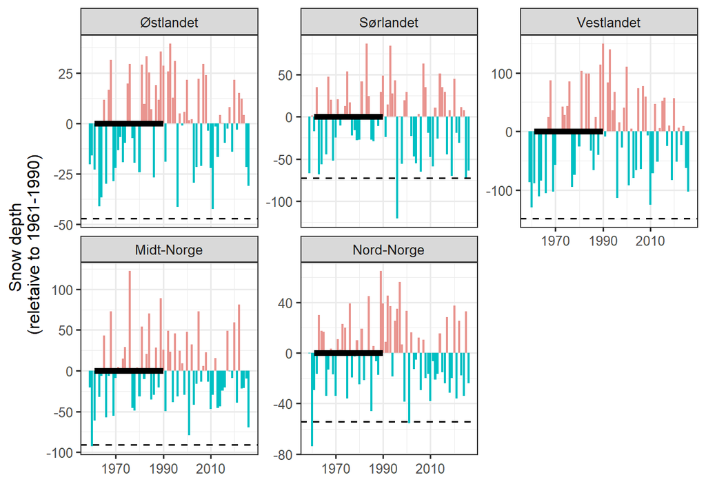

Figure 2: Alpine snow depth relative to the perdion 1961-1990 indicator by the black horisonal bar.

```r
regOrder = c("Østlandet","Sørlandet","Vestlandet","Midt-Norge","Nord-Norge")

results_normalised %>%
  mutate(
    diff = mean_snow - x100,
    x60_centered = x60 - x100,
    col = if_else(mean_snow>= x100, "1", "2")) %>%
  ggplot(aes(x = as.numeric(year),
           y = diff, fill = col))+
  geom_bar(stat="identity")+
  geom_hline(aes(yintercept = x60_centered),
        linetype=2)+
  geom_segment(x = 1961, xend=1990,
               y = 0, yend = 0,
               linewidth=2)+
  scale_fill_hue(l=70, c=60)+
  theme_bw(base_size = 12)+
  ylab("Snow depth \n(reletaive to 1961-1990)")+
  #ylab("Snødybde\n(avvik fra 1961-1990)")+
  xlab("")+
  guides(fill="none")+
  facet_wrap( .~ factor(region, levels = regOrder),
              ncol=3,
              scales = "free_y")
```

We combine the indicator values over 5 years to average out some interannual variation. Therefore the indicator value for 2024 uses data from 2020 to 2024. We use the temporal variation across these five years as the indicator uncertainty. To describe the uncertainty in the estimates, we first get the sd of the regional indicator values across the five years in the reporting period and draw 1000 values from a logit scale, and then backtransform (Figure 3).

```r
results_period <- results_normalised |>
  mutate(
    closing_year = case_when(
      #year %in% reference_years ~ "reference",
      year %in% accounting_period_1 ~ "2024",
      year %in% accounting_period_2 ~ "2019",
      .default = "drop"
    )
  ) |>
  dplyr::filter(closing_year != "drop") |>
  group_by(id, region, arealFjell, closing_year) |>
  summarise(
    indicator = mean(condition_score),
    sd = sd(condition_score)
  )

results_distr <- results_period |>
  mutate(
    eta = qlogis(indicator),
    sd_eta = sd/(indicator*(1-indicator)),
    indicator = list(plogis(rnorm(1000, eta, sd_eta)))) |>
  unnest(indicator) |>
  ungroup() |>
  select(part = region, year = closing_year, indicator, arealFjell )
```

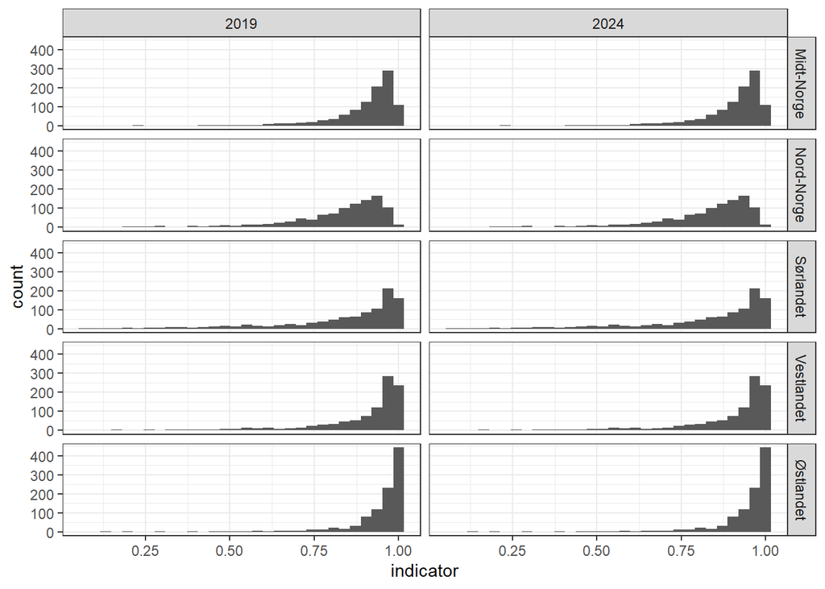

Figure 3: Indicator values represented as probability distributions.

```r
results_distr |>
  ggplot(aes(x = indicator)) +
  geom_histogram() +
  facet_grid(cols = vars(year), rows = vars(part)) +
  theme_bw()
```

Then we propagate these uncertainty and get a national estimate.

```r
results_distr_norway <- results_distr |>
  add_column(end = "Norway") |>
  ecTools::ec_upscale(
    variable = indicator,
    weight = arealFjell,
    start_units = part,
    end_units = end,
    year = year,
    end_units_name = "part",
    n = 1000
  )

# Append to dataset
out_data <- results_distr |>
  select(part, year, sampled_mean = indicator) |>
  bind_rows(results_distr_norway)
```

## 10. Results

```r
out_data |>
  group_by(part, year) |>
  summarise(indicator = median(sampled_mean),
   lower = round(quantile(sampled_mean, probs = 0.025), 2),
   upper = round(quantile(sampled_mean, probs = 0.975), 2)) |>
    unite("95% CI", c("lower", "upper"), sep = " - ") |>
    select(part, year, indicator, '95% CI') |>
  kable(
    digits = 2,
    caption = paste(
      "Indicator values for NO_SNOW_001 (snow depth in alpine ecosystems)"
    )
  )
```

Indicator values for NO_SNOW_001 (snow depth in alpine ecosystems)

| part | year | indicator | 95% CI |
| --- | --- | --- | --- |
| Midt-Norge | 2019 | 0.94 | 0.65 - 0.99 |
| Midt-Norge | 2024 | 0.94 | 0.65 - 0.99 |
| Nord-Norge | 2019 | 0.87 | 0.45 - 0.98 |
| Nord-Norge | 2024 | 0.87 | 0.45 - 0.98 |
| Norway | 2019 | 0.89 | 0.68 - 0.96 |
| Norway | 2024 | 0.89 | 0.67 - 0.96 |
| Sørlandet | 2019 | 0.91 | 0.31 - 1 |
| Sørlandet | 2024 | 0.91 | 0.31 - 1 |
| Vestlandet | 2019 | 0.96 | 0.46 - 1 |
| Vestlandet | 2024 | 0.96 | 0.46 - 1 |
| Østlandet | 2019 | 0.98 | 0.65 - 1 |
| Østlandet | 2024 | 0.98 | 0.65 - 1 |

```r
arrow::write_parquet(
  out_data,
  "data/snow_indicator_fjell_by_region_winter_year_normalised.parquet"
)
```

## 12. Author contributions

**CRediT statement**

- Conceptualization: AK,MG
- Methodology: MG, AK
- Data curation: MG, AK
- Formal analysis: MG, AK
- Software: MG, AK
- Validation: MG, AK
- Visualization: MG, AK
- Writing – original draft: MG
- Writing – review & editing: AK

**Session Info**

This workflow uses `renv`. Run `renv::restore()` to recreate the working environment.